# Heart Disease Prediction

## 1. Data description

Dataset: https://www.kaggle.com/ronitf/heart-disease-uci

This database contains 76 attributes, but all published experiments refer to using a subset of 14 of them. In particular, the Cleveland database is the only one that has been used by ML researchers to this date.

Attribute Information:

- age
- sex (1 = male, 0 = female)
- cp: chest pain type (1 = typical angina, 2 = atypical angina, 3 = non-anginal pain, 4 = asymptomatic)
- trestbps: resting blood pressure
- chol: serum cholestoral in mg/dl
- fbs: fasting blood sugar (> 120 mg/dl, 1 = true; 0 = false)
- restecg: resting electrocardiographic results (0 = normal, 1 = having ST-T wave abnormality, 2 = showing probable or definite left ventricular hypertrophy by Estes' criteria)
- thalach: maximum heart rate achieved
- exang: exercise induced angina(1 = yes; 0 = no)
- oldpeak = ST depression induced by exercise relative to rest
- slope: the slope of the peak exercise ST segment(1 = upsloping, 2 = flat, 3 = downsloping)
- ca: number of major vessels (0-3) colored by flourosopy
- thal: thalassemia (1 = normal; 2 = fixed defect; 3 = reversable defect)
- target: Heart disease (0 = no, 1 = yes)

## 2. Load & Explore the dataset

```python
import pandas as pd
data = pd.read_csv("heart.csv")
df = data.copy()
```

```python
df.head()
```

|  | age | sex | cp | trestbps | chol | fbs | restecg | thalach | exang | oldpeak | slope | ca | thal | target |
| --- | --- | --- | --- | --- | --- | --- | --- | --- | --- | --- | --- | --- | --- | --- |
| 0 | 63 | 1 | 3 | 145 | 233 | 1 | 0 | 150 | 0 | 2.3 | 0 | 0 | 1 | 1 |
| 1 | 37 | 1 | 2 | 130 | 250 | 0 | 1 | 187 | 0 | 3.5 | 0 | 0 | 2 | 1 |
| 2 | 41 | 0 | 1 | 130 | 204 | 0 | 0 | 172 | 0 | 1.4 | 2 | 0 | 2 | 1 |
| 3 | 56 | 1 | 1 | 120 | 236 | 0 | 1 | 178 | 0 | 0.8 | 2 | 0 | 2 | 1 |
| 4 | 57 | 0 | 0 | 120 | 354 | 0 | 1 | 163 | 1 | 0.6 | 2 | 0 | 2 | 1 |

```python
df.shape
```

```
(303, 14)
```

```python
#NO NaN values
df.isna().sum()
```

```
age         0
sex         0
cp          0
trestbps    0
chol        0
fbs         0
restecg     0
thalach     0
exang       0
oldpeak     0
slope       0
ca          0
thal        0
target      0
dtype: int64
```

```python
df.dtypes
```

```
age           int64
sex           int64
cp            int64
trestbps      int64
chol          int64
fbs           int64
restecg       int64
thalach       int64
exang         int64
oldpeak     float64
slope         int64
ca            int64
thal          int64
target        int64
dtype: object
```

```python
df.describe(include='all')
```

|  | age | sex | cp | trestbps | chol | fbs | restecg | thalach | exang | oldpeak | slope | ca | thal | target |
| --- | --- | --- | --- | --- | --- | --- | --- | --- | --- | --- | --- | --- | --- | --- |
| count | 303.000000 | 303.000000 | 303.000000 | 303.000000 | 303.000000 | 303.000000 | 303.000000 | 303.000000 | 303.000000 | 303.000000 | 303.000000 | 303.000000 | 303.000000 | 303.000000 |
| mean | 54.366337 | 0.683168 | 0.966997 | 131.623762 | 246.264026 | 0.148515 | 0.528053 | 149.646865 | 0.326733 | 1.039604 | 1.399340 | 0.729373 | 2.313531 | 0.544554 |
| std | 9.082101 | 0.466011 | 1.032052 | 17.538143 | 51.830751 | 0.356198 | 0.525860 | 22.905161 | 0.469794 | 1.161075 | 0.616226 | 1.022606 | 0.612277 | 0.498835 |
| min | 29.000000 | 0.000000 | 0.000000 | 94.000000 | 126.000000 | 0.000000 | 0.000000 | 71.000000 | 0.000000 | 0.000000 | 0.000000 | 0.000000 | 0.000000 | 0.000000 |
| 25% | 47.500000 | 0.000000 | 0.000000 | 120.000000 | 211.000000 | 0.000000 | 0.000000 | 133.500000 | 0.000000 | 0.000000 | 1.000000 | 0.000000 | 2.000000 | 0.000000 |
| 50% | 55.000000 | 1.000000 | 1.000000 | 130.000000 | 240.000000 | 0.000000 | 1.000000 | 153.000000 | 0.000000 | 0.800000 | 1.000000 | 0.000000 | 2.000000 | 1.000000 |
| 75% | 61.000000 | 1.000000 | 2.000000 | 140.000000 | 274.500000 | 0.000000 | 1.000000 | 166.000000 | 1.000000 | 1.600000 | 2.000000 | 1.000000 | 3.000000 | 1.000000 |
| max | 77.000000 | 1.000000 | 3.000000 | 200.000000 | 564.000000 | 1.000000 | 2.000000 | 202.000000 | 1.000000 | 6.200000 | 2.000000 | 4.000000 | 3.000000 | 1.000000 |

```python
#unique values: actually categorical variables
import pandas as pd
import numpy as np
for i in df.columns:
    uniquevalues=pd.unique(df[i])
    if(len(uniquevalues)<20):
        print(i,np.sort(uniquevalues))
#except for ca
```

```
sex [0 1]
cp [0 1 2 3]
fbs [0 1]
restecg [0 1 2]
exang [0 1]
slope [0 1 2]
ca [0 1 2 3 4]
thal [0 1 2 3]
target [0 1]
```

```python
#unique values: actually numerical variables
import pandas as pd
for i in df.columns:
    unique=pd.unique(df[i])
    if(len(unique)>20):
        print(i,[df[i].min(),df[i].max()])
```

```
age [29, 77]
trestbps [94, 200]
chol [126, 564]
thalach [71, 202]
oldpeak [0.0, 6.2]
```

## 3. Initial Thoughts

- 303 entries with 14 variables - 13 of them can be predictors.
- No missing values. :) Great!
- All the values in the dataframe is "numerical" - however, 7 of the predictors are actually categorical and are encoded to integers.  
  categorical variables: sex, cp, fbs, restecg, exang, slope, thal.  
  numerical variables: age, trestbps, chol, thalach, oldpeak, ca.  
  The categorical ones should be converted into categorical variables (and then make them into dummy variables when needed for the model).

## 4. Data Wrangling

```python
#for sex
df.loc[df.sex==0, 'sex'] = "female"
df.loc[df.sex==1, 'sex'] = "male"
#for cp
df.loc[df.cp==1, 'cp'] = "typical angina"
df.loc[df.cp==2, 'cp'] = "atypical angina"
df.loc[df.cp==3, 'cp'] = "non-anginal pain"
df.loc[df.cp==4, 'cp'] = "asymptomatic chest pain"
#for fbs
df.loc[df.fbs==1,'fbs']="fbs greater than 120"
df.loc[df.fbs==0,'fbs']="fbs lower than 120"
#for restecg
df.loc[df.restecg==0,'restecg']="restecg normal"
df.loc[df.restecg==1,'restecg']="ST-T wave abnormality"
df.loc[df.restecg==2,'restecg']="left ventricular hypertrophy"
#for exang
df.loc[df.exang==0,'exang']="no exercise induced angina"
df.loc[df.exang==1,'exang']="exercise induced angina"
#for slope
df.loc[df.slope==1,'slope']="upsloping"
df.loc[df.slope==2,'slope']="flat"
df.loc[df.slope==3,'slope']="downsloping"
#thal
df.loc[df.thal==1,'thal']="normal thal"
df.loc[df.thal==2,'thal']="fixed defect"
df.loc[df.thal==3,'thal']="reversable defect"
```

```python
#drop the rows that thal not described(2 rows)
#df[df.thal==0]
df=df[df.thal!=0]
```

```python
list(df.select_dtypes(include=['object']).columns)
```

```
['sex', 'cp', 'fbs', 'restecg', 'exang', 'slope', 'thal']
```

## 5. Modeling

### Aim:

For potential disease detecting purpose, we should care most about how many people that have heart disease(true=1) that found out to have heart disease(predict=1) by our prediction. That's recall for the positive(1, in sklearn) class.  
We should focus on other performance metrics as well...

```python
# get dummy variables
df = pd.get_dummies(df,drop_first=True)
#drop_first: Whether to get k-1 dummies out of k categorical levels by removing the first level.(reduce redundant columns)
#https://stackoverflow.com/questions/50176096/removing-redundant-columns-when-using-get-dummies
df.head()
```

|  | age | trestbps | chol | thalach | oldpeak | ca | target | sex_male | cp_atypical angina | cp_non-anginal pain | cp_typical angina | fbs_fbs lower than 120 | restecg_left ventricular hypertrophy | restecg_restecg normal | exang_no exercise induced angina | slope_flat | slope_upsloping | thal_normal thal | thal_reversable defect |
| --- | --- | --- | --- | --- | --- | --- | --- | --- | --- | --- | --- | --- | --- | --- | --- | --- | --- | --- | --- |
| 0 | 63 | 145 | 233 | 150 | 2.3 | 0 | 1 | 1 | 0 | 1 | 0 | 0 | 0 | 1 | 1 | 0 | 0 | 1 | 0 |
| 1 | 37 | 130 | 250 | 187 | 3.5 | 0 | 1 | 1 | 1 | 0 | 0 | 1 | 0 | 0 | 1 | 0 | 0 | 0 | 0 |
| 2 | 41 | 130 | 204 | 172 | 1.4 | 0 | 1 | 0 | 0 | 0 | 1 | 1 | 0 | 1 | 1 | 1 | 0 | 0 | 0 |
| 3 | 56 | 120 | 236 | 178 | 0.8 | 0 | 1 | 1 | 0 | 0 | 1 | 1 | 0 | 0 | 1 | 1 | 0 | 0 | 0 |
| 4 | 57 | 120 | 354 | 163 | 0.6 | 0 | 1 | 0 | 0 | 0 | 0 | 1 | 0 | 0 | 0 | 1 | 0 | 0 | 0 |

```python
#separate predictors and response variable
train_features = df.columns.drop('target').tolist()
X_df = df[train_features]
y_df = df['target']

# Create training and test sets
from sklearn.model_selection import train_test_split
X_train, X_test, y_train, y_test = train_test_split(X_df, y_df, random_state = 0)#default: test_size=0.25

#scaling
from sklearn.preprocessing import MinMaxScaler
scaler = MinMaxScaler()
X_train_scaled = scaler.fit_transform(X_train)
X_test_scaled = scaler.transform(X_test)
```

### function: model performance on the test set

```python
from sklearn.metrics import roc_curve, auc, confusion_matrix, classification_report
from sklearn.metrics import accuracy_score, precision_score, recall_score, f1_score
import matplotlib.pyplot as plt

def model_performance_testset(model, X_train, y_train, X_test, y_test, pos_label=1):#positive class label, default=1

    #predicted value
    print("==================predicted values==================")
    y_predicted=model.predict(X_test)
    if len(y_predicted)<20:
        print(y_predicted)
    else:
        print(y_predicted[0:21])

    #4 metrics for the positive class
    print("\n=========================metrics=========================")
    print('Accuracy: {:.2f}'.format(accuracy_score(y_test, y_predicted)))
    print('Precision: {:.2f}'.format(precision_score(y_test, y_predicted,pos_label=pos_label)))
    print('Recall: {:.2f}'.format(recall_score(y_test, y_predicted,pos_label=pos_label)))
    print('F1: {:.2f}'.format(f1_score(y_test, y_predicted,pos_label=pos_label)))

    #report(for each class)
    print("\n================classification report for each class: ===============")
    print(classification_report(y_test, y_predicted))

    #confusion matrix
    print("\n==================confusion matrix: ===================")
    confusion = confusion_matrix(y_test, y_predicted)
    print(confusion)
    return("=================finished summarization :)==================")

def model_auc(model, X_train, y_train, X_test, y_test, pos_label=1):
    #auc
    print("\n==================auc: ===================")
    y_score_lr=model.fit(X_train, y_train).decision_function(X_test)
    fpr_lr, tpr_lr, _ = roc_curve(y_test, y_score_lr)
    auc_value = auc(fpr_lr, tpr_lr)
    print("auc={}".format(auc_value))

    #auc plot
    plt.figure()
    plt.xlim([-0.01, 1.00])
    plt.ylim([-0.01, 1.01])
    plt.plot(fpr_lr, tpr_lr, lw=3, label='ROC curve (auc = {:0.2f})'.format(auc_value))
    plt.xlabel('False Positive Rate', fontsize=16)
    plt.ylabel('True Positive Rate', fontsize=16)
    plt.title('ROC curve', fontsize=16)
    plt.legend(loc='lower right', fontsize=13)
    plt.plot([0, 1], [0, 1], color='navy', lw=3, linestyle='--')
    plt.show()
    return("=================finished auc :)==================")
```

### function: model performance using CV

```python
from sklearn.model_selection import cross_val_score
def CV_metrics(model, X_train, y_train, cv=5):
    #the model SHOULD NOT be fitted#

    #accuracy
    cv_scores_accuracy = np.mean(cross_val_score(model, X_train, y_train, cv=cv))
    print('Mean cross-validation (accuracy) (5-fold): {:.3f}\n'.format(cv_scores_accuracy))

    #auc
    cv_scores_accuracy = np.mean(cross_val_score(model, X_train, y_train, cv=cv, scoring = 'roc_auc'))
    print('Mean cross-validation (auc) (5-fold): {:.3f}\n'.format(cv_scores_accuracy))

    #recall (for 1 class)
    cv_scores_recall = np.mean(cross_val_score(model, X_train, y_train, cv=cv, scoring = 'recall'))
    print('Mean cross-validation (recall) (5-fold): {:.3f}\n'.format(cv_scores_recall))

    #precision (for 1 class)
    cv_scores_precision = np.mean(cross_val_score(model, X_train, y_train, cv=cv, scoring = 'precision'))
    print('Mean cross-validation (precision) (5-fold): {:.3f}\n'.format(cv_scores_precision))

    return("=================finished CV summarization :)==================")
```

### (1) Logistic regression

```python
from sklearn.model_selection import cross_val_score
from sklearn.linear_model import LogisticRegression
from sklearn.svm import SVC
from sklearn.ensemble import RandomForestClassifier
from sklearn.svm import SVC
from sklearn.model_selection import GridSearchCV
from sklearn.metrics import roc_auc_score
from sklearn.ensemble import GradientBoostingClassifier
from sklearn.neighbors import KNeighborsClassifier
```

```python
#logistic: grid search for the best parameter C
clf = LogisticRegression(max_iter=10000)
grid_values = {'C': [0.01, 0.1, 1, 10, 50, 100]}#values
grid_clf_acc = GridSearchCV(clf, param_grid = grid_values, scoring="recall").fit(X_train_scaled, y_train)
predict_test=grid_clf_acc.predict(X_test_scaled) #Call predict on the estimator with the best found parameters.
print('Grid best parameter (max. recall): ', grid_clf_acc.best_params_)
print('Grid best score (recall): ', grid_clf_acc.best_score_)
print('Test set recall: ', recall_score(y_test, predict_test))
```

```
Grid best parameter (max. recall):  {'C': 0.01}
Grid best score (recall):  0.9526153846153846
Test set recall:  0.9473684210526315
```

```python
logistic_clf = LogisticRegression(C=0.01,max_iter=10000)
logistic_clf.fit(X_train_scaled,y_train)
```

```
LogisticRegression(C=0.01, max_iter=10000)
```

### (2) Random Forest

```python
randomforest_clf= RandomForestClassifier()
grid_values = {'max_depth': [2,3,4,5,6]}
grid_ranfor_recall = GridSearchCV(randomforest_clf, param_grid = grid_values, scoring="recall").fit(X_train_scaled, y_train)
predict_test_ranfor=grid_ranfor_recall.predict(X_test_scaled)
print('Grid best parameter (max. recall): ', grid_ranfor_recall.best_params_)
print('Grid best score (recall): ', grid_ranfor_recall.best_score_)
print('Test set recall: ', recall_score(y_test, predict_test_ranfor))
```

```
Grid best parameter (max. recall):  {'max_depth': 3}
Grid best score (recall):  0.8652307692307692
Test set recall:  0.9473684210526315
```

```python
randomforest_clf= RandomForestClassifier(max_depth=3).fit(X_train_scaled,y_train)
```

### (3) Gradient-boosted decision trees

```python
gbdt_clf = GradientBoostingClassifier()
grid_values = {'learning_rate': [0.005,0.01,0.05,0.1],
               'max_depth':[2,3,4,5,6]}
grid_gbdt_recall = GridSearchCV(gbdt_clf, param_grid = grid_values, scoring="recall").fit(X_train_scaled, y_train)
predict_test_gbdt=grid_gbdt_recall.predict(X_test_scaled)
print('Grid best parameter (max. recall): ', grid_gbdt_recall.best_params_)
print('Grid best score (recall): ', grid_gbdt_recall.best_score_)
print('Test set recall: ', recall_score(y_test, predict_test_gbdt))
```

```
Grid best parameter (max. recall):  {'learning_rate': 0.005, 'max_depth': 3}
Grid best score (recall):  0.8649230769230769
Test set recall:  0.9210526315789473
```

```python
gbdt_clf = GradientBoostingClassifier(learning_rate=0.005, max_depth=3).fit(X_train_scaled,y_train)
```

### (4) SVM

```python
svm_clf = SVC()
grid_values = {'kernel': ['rbf', 'poly'],
               'gamma':[0.001, 1, 5, 10],
               'C':[0.1, 1, 15, 100]}
#grid_svm_recall = GridSearchCV(svm_clf, param_grid = grid_values, scoring="accuracy").fit(X_train_scaled, y_train)
#A bad one, predict all 1s.
grid_svm_recall = GridSearchCV(svm_clf, param_grid = grid_values, scoring="recall").fit(X_train_scaled, y_train)
predict_test_svm=grid_svm_recall.predict(X_test_scaled)
print('Grid best parameter (max. recall): ', grid_svm_recall.best_params_)
print('Grid best score (recall): ', grid_svm_recall.best_score_)
print('Test set recall: ', recall_score(y_test, predict_test_svm))
```

```
Grid best parameter (max. recall):  {'C': 100, 'gamma': 0.001, 'kernel': 'rbf'}
Grid best score (recall):  0.8266666666666668
Test set recall:  0.8947368421052632
```

```python
svm_clf = SVC(kernel='rbf',gamma=0.001,C=100).fit(X_train_scaled,y_train)
```

### (5) KNN

```python
knn_clf = KNeighborsClassifier()
grid_values = {'n_neighbors': [3, 5, 7, 9, 12]}
grid_knn_recall = GridSearchCV(knn_clf, param_grid = grid_values, scoring="recall").fit(X_train_scaled, y_train)#accuracy
predict_test_knn=grid_knn_recall.predict(X_test_scaled)
print('Grid best parameter (max. recall): ', grid_knn_recall.best_params_)
print('Grid best score (recall): ', grid_knn_recall.best_score_)
print('Test set recall: ', recall_score(y_test, predict_test_knn))
```

```
Grid best parameter (max. recall):  {'n_neighbors': 9}
Grid best score (recall):  0.8329230769230769
Test set recall:  0.8947368421052632
```

```python
knn_clf = KNeighborsClassifier(n_neighbors=9).fit(X_train_scaled,y_train)
```

### (6) MLPclassifier

```python
from sklearn.neural_network import MLPClassifier

mlp_clf = MLPClassifier(hidden_layer_sizes = [500, 5], max_iter = 10000)
grid_values = {'alpha': [0.01, 0.1, 1.0, 5.0]}
grid_mlp_recall = GridSearchCV(mlp_clf, param_grid = grid_values, scoring="recall").fit(X_train_scaled, y_train)
predict_test_mlp=grid_mlp_recall.predict(X_test_scaled)
print('Grid best parameter (max. recall): ', grid_mlp_recall.best_params_)
print('Grid best score (recall): ', grid_mlp_recall.best_score_)
print('Test set recall: ', recall_score(y_test, predict_test_mlp))
```

```
Grid best parameter (max. recall):  {'alpha': 5.0}
Grid best score (recall):  0.8886153846153846
Test set recall:  0.9473684210526315
```

```python
mlp_clf = MLPClassifier(hidden_layer_sizes = [500, 5], max_iter = 10000, alpha=5)
mlp_clf.fit(X_train_scaled,y_train)
```

```
MLPClassifier(alpha=5, hidden_layer_sizes=[500, 5], max_iter=10000)
```

## 7. Model-selection (test set and CV)

### (1) Logistic regression

```python
model_performance_testset(logistic_clf,X_train_scaled, y_train, X_test_scaled, y_test)
```

```
==================predicted values==================
[0 1 0 0 1 0 0 1 1 1 0 1 0 1 1 1 1 1 1 1 1]

=========================metrics=========================
Accuracy: 0.78
Precision: 0.71
Recall: 0.95
F1: 0.81

================classification report for each class: ===============
              precision    recall  f1-score   support

           0       0.92      0.61      0.73        38
           1       0.71      0.95      0.81        38

    accuracy                           0.78        76
   macro avg       0.81      0.78      0.77        76
weighted avg       0.81      0.78      0.77        76


==================confusion matrix: ===================
[[23 15]
 [ 2 36]]
```

```
'=================finished summarization :)=================='
```

```
==================auc: ===================
auc=0.9106648199445984
```

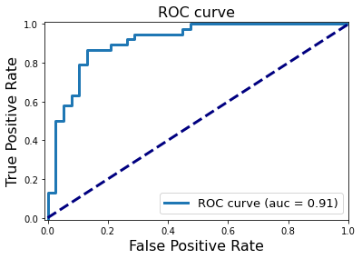

```
'=================finished auc :)=================='
```

```python
model_auc(logistic_clf,X_train_scaled, y_train, X_test_scaled, y_test)
```

```python
CV_metrics(LogisticRegression(C=0.01,max_iter=10000),X_train_scaled, y_train)
```

```
Mean cross-validation (accuracy) (5-fold): 0.738

Mean cross-validation (auc) (5-fold): 0.884

Mean cross-validation (recall) (5-fold): 0.953

Mean cross-validation (precision) (5-fold): 0.696
```

```
'=================finished CV summarization :)=================='
```

### (2) Random Forest

```python
model_performance_testset(randomforest_clf,X_train_scaled, y_train, X_test_scaled, y_test)
```

```
==================predicted values==================
[0 1 0 0 1 0 0 0 1 0 0 1 0 1 1 1 1 1 1 1 1]

=========================metrics=========================
Accuracy: 0.86
Precision: 0.80
Recall: 0.95
F1: 0.87

================classification report for each class: ===============
              precision    recall  f1-score   support

           0       0.94      0.76      0.84        38
           1       0.80      0.95      0.87        38

    accuracy                           0.86        76
   macro avg       0.87      0.86      0.85        76
weighted avg       0.87      0.86      0.85        76


==================confusion matrix: ===================
[[29  9]
 [ 2 36]]
```

```
'=================finished summarization :)=================='
```

```python
CV_metrics(RandomForestClassifier(max_depth=3),X_train_scaled, y_train)
```

```
Mean cross-validation (accuracy) (5-fold): 0.804

Mean cross-validation (auc) (5-fold): 0.887

Mean cross-validation (recall) (5-fold): 0.881

Mean cross-validation (precision) (5-fold): 0.806
```

```
'=================finished CV summarization :)=================='
```

### (3) Gradient-boosted decision trees

```python
model_performance_testset(gbdt_clf,X_train_scaled, y_train, X_test_scaled, y_test)
```

```
==================predicted values==================
[0 1 0 0 1 0 0 0 0 0 0 1 0 1 1 1 1 1 1 1 1]

=========================metrics=========================
Accuracy: 0.83
Precision: 0.78
Recall: 0.92
F1: 0.84

================classification report for each class: ===============
              precision    recall  f1-score   support

           0       0.90      0.74      0.81        38
           1       0.78      0.92      0.84        38

    accuracy                           0.83        76
   macro avg       0.84      0.83      0.83        76
weighted avg       0.84      0.83      0.83        76


==================confusion matrix: ===================
[[28 10]
 [ 3 35]]
```

```
'=================finished summarization :)=================='
```

```python
CV_metrics(GradientBoostingClassifier(learning_rate=0.005, max_depth=3),X_train_scaled, y_train)
```

```
Mean cross-validation (accuracy) (5-fold): 0.760

Mean cross-validation (auc) (5-fold): 0.826

Mean cross-validation (recall) (5-fold): 0.865

Mean cross-validation (precision) (5-fold): 0.748
```

```
'=================finished CV summarization :)=================='
```

### (4) SVM

```python
model_performance_testset(svm_clf,X_train_scaled, y_train, X_test_scaled, y_test)
```

```
==================predicted values==================
[0 1 0 0 1 0 0 1 1 1 0 1 0 1 1 1 1 1 1 1 1]

=========================metrics=========================
Accuracy: 0.83
Precision: 0.79
Recall: 0.89
F1: 0.84

================classification report for each class: ===============
              precision    recall  f1-score   support

           0       0.88      0.76      0.82        38
           1       0.79      0.89      0.84        38

    accuracy                           0.83        76
   macro avg       0.83      0.83      0.83        76
weighted avg       0.83      0.83      0.83        76


==================confusion matrix: ===================
[[29  9]
 [ 4 34]]
```

```
'=================finished summarization :)=================='
```

```
==================auc: ===================
auc=0.9099722991689752
```

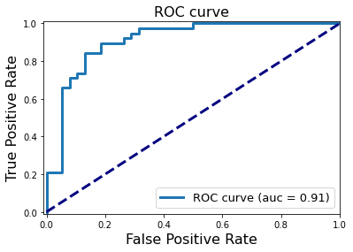

```
'=================finished auc :)=================='
```

```python
model_auc(svm_clf,X_train_scaled, y_train, X_test_scaled, y_test)
```

```python
CV_metrics(SVC(kernel='rbf',gamma=0.001,C=100),X_train_scaled, y_train)
```

[output not shown]

```
'=================finished CV summarization :)=================='
```

### (5) KNN

```python
model_performance_testset(knn_clf,X_train_scaled, y_train, X_test_scaled, y_test)
```

```
==================predicted values==================
[0 1 0 0 1 0 0 1 1 1 0 1 0 1 1 1 1 1 1 1 1]

=========================metrics=========================
Accuracy: 0.86
Precision: 0.83
Recall: 0.89
F1: 0.86

================classification report for each class: ===============
              precision    recall  f1-score   support

           0       0.89      0.82      0.85        38
           1       0.83      0.89      0.86        38

    accuracy                           0.86        76
   macro avg       0.86      0.86      0.86        76
weighted avg       0.86      0.86      0.86        76


==================confusion matrix: ===================
[[31  7]
 [ 4 34]]
```

```
'=================finished summarization :)=================='
```

```python
CV_metrics(KNeighborsClassifier(n_neighbors=9),X_train_scaled, y_train)
```

```
Mean cross-validation (accuracy) (5-fold): 0.818

Mean cross-validation (auc) (5-fold): 0.880

Mean cross-validation (recall) (5-fold): 0.833

Mean cross-validation (precision) (5-fold): 0.840
```

```
'=================finished CV summarization :)=================='
```

### (6) MLP classifier

```python
model_performance_testset(mlp_clf,X_train_scaled, y_train, X_test_scaled, y_test)
```

```
==================predicted values==================
[0 1 0 0 1 0 0 1 1 1 0 1 0 1 1 1 1 1 1 1 1]

=========================metrics=========================
Accuracy: 0.83
Precision: 0.77
Recall: 0.95
F1: 0.85

================classification report for each class: ===============
              precision    recall  f1-score   support

           0       0.93      0.71      0.81        38
           1       0.77      0.95      0.85        38

    accuracy                           0.83        76
   macro avg       0.85      0.83      0.83        76
weighted avg       0.85      0.83      0.83        76


==================confusion matrix: ===================
[[27 11]
 [ 2 36]]
```

```
'=================finished summarization :)=================='
```

```python
CV_metrics(MLPClassifier(hidden_layer_sizes = [500, 5], max_iter = 10000, alpha=5),X_train_scaled, y_train)
```

```
Mean cross-validation (accuracy) (5-fold): 0.844

Mean cross-validation (auc) (5-fold): 0.898

Mean cross-validation (recall) (5-fold): 0.873

Mean cross-validation (precision) (5-fold): 0.839
```

```
'=================finished CV summarization :)=================='
```